# Co2_2020_prediction

**Made By DAHOU RENAUD L. Data Scientist in Benin**

- Whatsapp: +22967927952
- Email: dahou.r@yahoo.com

[figure not shown]

### À propos de cet ensemble de données

Les Indicateurs du développement dans le monde de la Banque mondiale contiennent plus d'un millier d'indicateurs annuels du développement économique de centaines de pays à travers le monde.

## Connexion à notre répertoire

```python
from google.colab import drive
drive.mount('/content/drive/')
```

```python
#!jupyter nbconvert --to html Co2_2020_prediction.ipynb
```

[output not shown]

# Télechargement de la base de donnée

```python
import warnings
warnings.filterwarnings("ignore")
```

```python
import os
os.chdir("/content/drive/My Drive/DATASCIENCE/Projet/World_Development_Indicators")
#os.environ['KAGGLE_USERNAME'] = "renauddahou" # username from the json file
#os.environ['KAGGLE_KEY'] = "d71c48839218770332fbf35e4ca29bdd" # key from the json file
#!kaggle datasets download -d worldbank/world-development-indicators # api copied from kaggle
```

```python
#!unzip world-development-indicators.zip
```

# Importation des librairies

```python
# Import libraries
import sqlite3 as sql # sql connector
from datetime import datetime
import numpy as np             #for numerical computations like log,exp,sqrt etc
import pandas as pd            #for reading & storing data, pre-processing
import matplotlib.pylab as plt #for visualization
#for making sure matplotlib plots are generated in Jupyter notebook itself
%matplotlib inline
from pandas import DataFrame
import matplotlib.pyplot as plt
import seaborn as sns
from datetime import datetime, timedelta
from statsmodels.tsa.arima_model import ARIMA
from statsmodels.tsa.statespace.sarimax import SARIMAX
from statsmodels.graphics.tsaplots import plot_acf, plot_pacf
from statsmodels.tsa.stattools import acf, pacf
from statsmodels.tsa.stattools import adfuller
from statsmodels.tsa.seasonal import seasonal_decompose
from scipy import stats
import statsmodels.api as sm
from itertools import product
from math import sqrt
from sklearn.metrics import mean_squared_error
from matplotlib.pylab import rcParams
rcParams['figure.figsize'] = 10, 6

import warnings
warnings.filterwarnings('ignore')

%matplotlib inline
```

# Connection à la base de donnée

```python
conn = sql.connect('database.sqlite')
tables = pd.read_sql("""SELECT *
                        FROM sqlite_master
                        WHERE type='table';""", conn)
tables
```

|  | type | name | tbl_name | rootpage | sql |
| --- | --- | --- | --- | --- | --- |
| 0 | table | Country | Country | 2 | CREATE TABLE Country (\n CountryCode TEXT,\... |
| 1 | table | CountryNotes | CountryNotes | 186 | CREATE TABLE CountryNotes (\n Countrycode T... |
| 2 | table | Series | Series | 948 | CREATE TABLE Series (\n SeriesCode TEXT,\n ... |
| 3 | table | Indicators | Indicators | 4448 | CREATE TABLE Indicators (\n CountryName TEX... |
| 4 | table | SeriesNotes | SeriesNotes | 1317550 | CREATE TABLE SeriesNotes (\n Seriescode TEX... |
| 5 | table | Footnotes | Footnotes | 1317587 | CREATE TABLE Footnotes (\n Countrycode TEXT... |

# Interrogation des tables

```python
tables_Country	 = pd.read_sql("""SELECT * FROM Country	;""", conn)
tables_Country.head(3)
```

|  | CountryCode | ShortName | TableName | LongName | Alpha2Code | CurrencyUnit | SpecialNotes | Region | IncomeGroup | Wb2Code | NationalAccountsBaseYear | NationalAccountsReferenceYear | SnaPriceValuation | LendingCategory | OtherGroups | SystemOfNationalAccounts | AlternativeConversionFactor | PppSurveyYear | BalanceOfPaymentsManualInUse | ExternalDebtReportingStatus | SystemOfTrade | GovernmentAccountingConcept | ImfDataDisseminationStandard | LatestPopulationCensus | LatestHouseholdSurvey | SourceOfMostRecentIncomeAndExpenditureData | VitalRegistrationComplete | LatestAgriculturalCensus | LatestIndustrialData | … |
| --- | --- | --- | --- | --- | --- | --- | --- | --- | --- | --- | --- | --- | --- | --- | --- | --- | --- | --- | --- | --- | --- | --- | --- | --- | --- | --- | --- | --- | --- | --- |
| 0 | AFG | Afghanistan | Afghanistan | Islamic State of Afghanistan | AF | Afghan afghani | Fiscal year end: March 20; reporting period fo... | South Asia | Low income | AF | 2002/03 |  | Value added at basic prices (VAB) | IDA | HIPC | Country uses the 1993 System of National Accou... |  |  |  | Actual | General trade system | Consolidated central government | General Data Dissemination System (GDDS) | 1979 | Multiple Indicator Cluster Survey (MICS), 2010/11 | Integrated household survey (IHS), 2008 |  | 2013/14 |  | … |
| 1 | ALB | Albania | Albania | Republic of Albania | AL | Albanian lek |  | Europe & Central Asia | Upper middle income | AL | Original chained constant price data are resca... | 1996 | Value added at basic prices (VAB) | IBRD |  | Country uses the 1993 System of National Accou... |  | Rolling | IMF Balance of Payments Manual, 6th edition. | Actual | General trade system | Budgetary central government | General Data Dissemination System (GDDS) | 2011 | Demographic and Health Survey (DHS), 2008/09 | Living Standards Measurement Study Survey (LSM... | Yes | 2012 | 2011 | … |
| 2 | DZA | Algeria | Algeria | People's Democratic Republic of Algeria | DZ | Algerian dinar |  | Middle East & North Africa | Upper middle income | DZ | 1980 |  | Value added at basic prices (VAB) | IBRD |  | Country uses the 1968 System of National Accou... |  | 2011 | IMF Balance of Payments Manual, 6th edition. | Actual | Special trade system | Budgetary central government | General Data Dissemination System (GDDS) | 2008 | Multiple Indicator Cluster Survey (MICS), 2012 | Integrated household survey (IHS), 1995 |  |  | 2010 | … |

```python
tables_CountryNotes	 = pd.read_sql("""SELECT * FROM CountryNotes ;""", conn)
tables_CountryNotes.head(3)
```

|  | Countrycode | Seriescode | Description |
| --- | --- | --- | --- |
| 0 | ABW | EG.EGY.PRIM.PP.KD | Sources: Estimated based on UN Energy Statisti... |
| 1 | ABW | EG.ELC.RNEW.ZS | Sources: UN Energy Statistics (2014) |
| 2 | ABW | EG.FEC.RNEW.ZS | Sources: UN Energy Statistics (2014) |

```python
tables_Series	 = pd.read_sql("""SELECT * FROM Series;""", conn)
tables_Series.head(3)
```

|  | SeriesCode | Topic | IndicatorName | ShortDefinition | LongDefinition | UnitOfMeasure | Periodicity | BasePeriod | OtherNotes | AggregationMethod | LimitationsAndExceptions | NotesFromOriginalSource | GeneralComments | Source | StatisticalConceptAndMethodology | DevelopmentRelevance | RelatedSourceLinks | OtherWebLinks | RelatedIndicators | LicenseType |
| --- | --- | --- | --- | --- | --- | --- | --- | --- | --- | --- | --- | --- | --- | --- | --- | --- | --- | --- | --- | --- |
| 0 | BN.KLT.DINV.CD | Economic Policy & Debt: Balance of payments: C... | Foreign direct investment, net (BoP, current US$) |  | Foreign direct investment are the net inflows ... |  | Annual |  |  |  |  |  | Note: Data are based on the sixth edition of t... | International Monetary Fund, Balance of Paymen... |  |  |  |  |  | Open |
| 1 | BX.KLT.DINV.WD.GD.ZS | Economic Policy & Debt: Balance of payments: C... | Foreign direct investment, net inflows (% of GDP) |  | Foreign direct investment are the net inflows ... |  | Annual |  |  | Weighted average | FDI data do not give a complete picture of int... |  | Note: Data starting from 2005 are based on the... | International Monetary Fund, International Fin... | Data on equity flows are based on balance of p... | Private financial flows - equity and debt - ac... |  |  |  | Open |
| 2 | BX.KLT.DINV.CD.WD | Economic Policy & Debt: Balance of payments: C... | Foreign direct investment, net inflows (BoP, c... |  | Foreign direct investment refers to direct inv... |  | Annual |  |  | Sum | FDI data do not give a complete picture of int... |  | Note: Data starting from 2005 are based on the... | International Monetary Fund, Balance of Paymen... | Data on equity flows are based on balance of p... | Private financial flows - equity and debt - ac... |  |  |  | Open |

```python
tables_Indicators	 = pd.read_sql("""SELECT * FROM Indicators;""", conn)
tables_Indicators.head(3)
```

|  | CountryName | CountryCode | IndicatorName | IndicatorCode | Year | Value |
| --- | --- | --- | --- | --- | --- | --- |
| 0 | Arab World | ARB | Adolescent fertility rate (births per 1,000 wo... | SP.ADO.TFRT | 1960 | 133.560907 |
| 1 | Arab World | ARB | Age dependency ratio (% of working-age populat... | SP.POP.DPND | 1960 | 87.797601 |
| 2 | Arab World | ARB | Age dependency ratio, old (% of working-age po... | SP.POP.DPND.OL | 1960 | 6.634579 |

```python
tables_SeriesNotes	 = pd.read_sql("""SELECT * FROM SeriesNotes;""", conn)
tables_SeriesNotes.head(3)
```

|  | Seriescode | Year | Description |
| --- | --- | --- | --- |
| 0 | SP.ADO.TFRT | YR1960 | Interpolated using data for 1957 and 1962. |
| 1 | SP.DYN.AMRT.FE | YR1960 | Interpolated using data for 1957 and 1962, if ... |
| 2 | SP.DYN.AMRT.MA | YR1960 | Interpolated using data for 1957 and 1962, if ... |

```python
tables_Footnotes = pd.read_sql("""SELECT * FROM Footnotes;""", conn)
tables_Footnotes.head(3)
```

|  | Countrycode | Seriescode | Year | Description |
| --- | --- | --- | --- | --- |
| 0 | ABW | AG.LND.FRST.K2 | YR1990 | Not specified |
| 1 | ABW | AG.LND.FRST.K2 | YR2000 | Not specified |
| 2 | ABW | AG.LND.FRST.K2 | YR2005 | Not specified |

### **Après avoir parcouru l'ensemble de la base de données revenons à la table qui nous intéresse la table des indicateurs de développement. Dans cette table nous allons nous intéresser au Bénin**

```python
Benin_data = tables_Indicators[tables_Indicators['CountryName'] == 'Benin']
Benin_data.head()
```

|  | CountryName | CountryCode | IndicatorName | IndicatorCode | Year | Value |
| --- | --- | --- | --- | --- | --- | --- |
| 5097 | Benin | BEN | Adolescent fertility rate (births per 1,000 wo... | SP.ADO.TFRT | 1960 | 85.762800 |
| 5098 | Benin | BEN | Age dependency ratio (% of working-age populat... | SP.POP.DPND | 1960 | 77.158049 |
| 5099 | Benin | BEN | Age dependency ratio, old (% of working-age po... | SP.POP.DPND.OL | 1960 | 8.895496 |
| 5100 | Benin | BEN | Age dependency ratio, young (% of working-age ... | SP.POP.DPND.YG | 1960 | 68.262553 |
| 5101 | Benin | BEN | Agriculture, value added (% of GDP) | NV.AGR.TOTL.ZS | 1960 | 46.157723 |

```python
Benin_data = Benin_data[['Year','IndicatorName','Value']]
Benin_data.head()
```

|  | Year | IndicatorName | Value |
| --- | --- | --- | --- |
| 5097 | 1960 | Adolescent fertility rate (births per 1,000 wo... | 85.762800 |
| 5098 | 1960 | Age dependency ratio (% of working-age populat... | 77.158049 |
| 5099 | 1960 | Age dependency ratio, old (% of working-age po... | 8.895496 |
| 5100 | 1960 | Age dependency ratio, young (% of working-age ... | 68.262553 |
| 5101 | 1960 | Agriculture, value added (% of GDP) | 46.157723 |

```python
pd.to_datetime(Benin_data['Year'],infer_datetime_format=True)
Benin_data=Benin_data.set_index('Year')
Benin_data.head()
```

| Year | IndicatorName | Value |
| --- | --- | --- |
| 1960 | Adolescent fertility rate (births per 1,000 wo... | 85.762800 |
| 1960 | Age dependency ratio (% of working-age populat... | 77.158049 |
| 1960 | Age dependency ratio, old (% of working-age po... | 8.895496 |
| 1960 | Age dependency ratio, young (% of working-age ... | 68.262553 |
| 1960 | Agriculture, value added (% of GDP) | 46.157723 |

```python
Benin_data.index
```

```
Int64Index([1960, 1960, 1960, 1960, 1960, 1960, 1960, 1960, 1960, 1960,
            ...
            2015, 2015, 2015, 2015, 2015, 2015, 2015, 2015, 2015, 2015],
           dtype='int64', name='Year', length=32965)
```

### **Voyons la liste des indicateurs de développements**

```python
IndicatorList=[]
for i in Benin_data.IndicatorName:
    if i not in IndicatorList:
        IndicatorList.append(i)
```

```python
IndicatorList
```

```
['Adolescent fertility rate (births per 1,000 women ages 15-19)',
 'Age dependency ratio (% of working-age population)',
 'Age dependency ratio, old (% of working-age population)',
 'Age dependency ratio, young (% of working-age population)',
 'Agriculture, value added (% of GDP)',
 'Agriculture, value added (current LCU)',
 'Agriculture, value added (current US$)',
 'Birth rate, crude (per 1,000 people)',
 'CO2 emissions (kg per 2005 US$ of GDP)',
 'CO2 emissions (kt)',
 'CO2 emissions (metric tons per capita)',
 'CO2 emissions from gaseous fuel consumption (% of total)',
 'CO2 emissions from gaseous fuel consumption (kt)',
 'CO2 emissions from liquid fuel consumption (% of total)',
 'CO2 emissions from liquid fuel consumption (kt)',
 'CO2 emissions from solid fuel consumption (% of total)',
 'CO2 emissions from solid fuel consumption (kt)',
 'Death rate, crude (per 1,000 people)',
 'DEC alternative conversion factor (LCU per US$)',
 'Discrepancy in expenditure estimate of GDP (current LCU)',
 'Exports as a capacity to import (constant LCU)',
 'Exports of goods and services (% of GDP)',
 'Exports of goods and services (constant 2005 US$)',
 'Exports of goods and services (constant LCU)',
 'Exports of goods and services (current LCU)',
 'Exports of goods and services (current US$)',
 'External balance on goods and services (% of GDP)',
 'External balance on goods and services (constant LCU)',
 'External balance on goods and services (current LCU)',
 'External balance on goods and services (current US$)',
 'Fertility rate, total (births per woman)',
 'Final consumption expenditure (constant 2005 US$)',
 'Final consumption expenditure (constant LCU)',
 'Final consumption expenditure (current LCU)',
 'Final consumption expenditure (current US$)',
 'Final consumption expenditure, etc. (% of GDP)',
 'Final consumption expenditure, etc. (constant 2005 US$)',
 'Final consumption expenditure, etc. (constant LCU)',
 'Final consumption expenditure, etc. (current LCU)',
 'Final consumption expenditure, etc. (current US$)',
```

[output cut: 946 more lines]

```
 'Net intake rate to Grade 1 of primary education, male (%)',
 'Poverty gap at $1.90 a day (2011 PPP) (%)',
 'Poverty gap at $3.10 a day (2011 PPP) (%)',
 'Poverty headcount ratio at $1.90 a day (2011 PPP) (% of population)',
 'Poverty headcount ratio at $3.10 a day (2011 PPP) (% of population)',
 'Self-employed, female (% of females employed)',
 'Self-employed, male (% of males employed)',
 'Self-employed, total (% of total employed)',
 'Start-up procedures to register a business (number)',
 'Time required to enforce a contract (days)',
 'Time required to start a business (days)',
 'Vulnerable employment, female (% of female employment)',
 'Vulnerable employment, male (% of male employment)',
 'Vulnerable employment, total (% of total employment)',
 ...]
```

## **Nous allons nous interreser aux divers sources d'émission du Co2**

Extraction des informations qui nous intéresse

```python
Benin_data_Co2_fuelkt = Benin_data[ (Benin_data.IndicatorName == 'CO2 emissions from gaseous fuel consumption (kt)') |
       (Benin_data.IndicatorName == 'CO2 emissions from liquid fuel consumption (kt)') |
       (Benin_data.IndicatorName == 'CO2 emissions from solid fuel consumption (kt)')]



Benin_data_Co2_fuelpct = Benin_data[ (Benin_data.IndicatorName == 'CO2 emissions from gaseous fuel consumption (% of total)') |
       (Benin_data.IndicatorName == 'CO2 emissions from liquid fuel consumption (% of total)') |
       (Benin_data.IndicatorName == 'CO2 emissions from solid fuel consumption (% of total)')]



Benin_data_Co2_sector = Benin_data[ (Benin_data.IndicatorName == 'CO2 emissions from electricity and heat production, total (% of total fuel combustion)') |
       (Benin_data.IndicatorName == 'CO2 emissions from manufacturing industries and construction (% of total fuel combustion)') |
       (Benin_data.IndicatorName == 'CO2 emissions from other sectors, excluding residential buildings and commercial and public services (% of total fuel combustion)') |
       (Benin_data.IndicatorName == 'CO2 emissions from residential buildings and commercial and public services (% of total fuel combustion)') |
       (Benin_data.IndicatorName == 'CO2 emissions from transport (% of total fuel combustion)')]


Benin_data_Co2_fuelkt=Benin_data_Co2_fuelkt.pivot(columns= 'IndicatorName', values= 'Value')
Benin_data_Co2_fuelpct=Benin_data_Co2_fuelpct.pivot(columns= 'IndicatorName', values= 'Value')
Benin_data_Co2_sector=Benin_data_Co2_sector.pivot(columns= 'IndicatorName', values= 'Value')
```

**Tracer des émissions de Co2 provenant des secteurs**

Comme on peut le constater les Co2 provenant d'autres secteurs que ceux cités sont inexistants.ce tracé montre que le Co2 émit dans la nature provient de la combustion de carburant 60% à 80% dans le secteur des transports

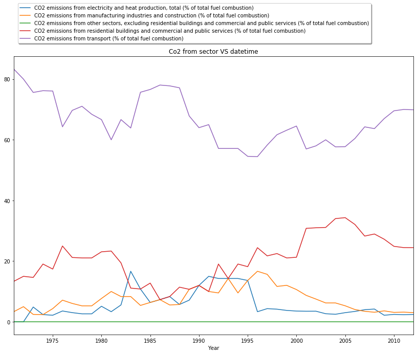

[figure not shown]

```python
import matplotlib.pyplot as plt

data1 = Benin_data_Co2_sector

# tracer des hypbands
ax = data1.sort_index().plot(figsize=(28,10))
chartBox = ax.get_position()
ax.set_position([chartBox.x0, chartBox.y0, chartBox.width*0.5, chartBox.height])
ax.legend(loc='upper right', bbox_to_anchor=(0.9, 1.2), shadow=True, ncol=1)
ax.set_title('Co2 from sector VS datetime' )
plt.show()


ax=data1.sort_index().plot.bar(figsize=(200,6))
chartBox = ax.get_position()
ax.set_position([chartBox.x0, chartBox.y0, chartBox.width*0.5, chartBox.height])
ax.legend(loc='upper left', bbox_to_anchor=(0.01, 1.2), shadow=True, ncol=3)
ax.set_title('Co2 from fuel% VS datetime' )
plt.show()
```

**Tracer des émissions de Co2 provenant des combustibles**

Comme on peut le constater les Co2 provenant de combustible gazeux et solide sont quasi inexistants

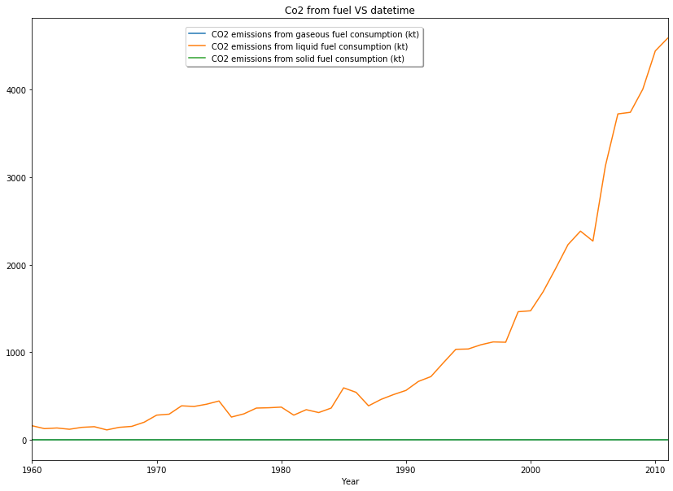

[figure not shown]

```python
import matplotlib.pyplot as plt

data1 = Benin_data_Co2_fuelkt

# tracer des hypbands
ax = data1.sort_index().plot(figsize=(28,10))
chartBox = ax.get_position()
ax.set_position([chartBox.x0, chartBox.y0, chartBox.width*0.5, chartBox.height])
ax.legend(loc='upper right', bbox_to_anchor=(0.62, 0.99), shadow=True, ncol=1)
ax.set_title('Co2 from fuel VS datetime' )
plt.show()


ax=Benin_data_Co2_fuelpct.sort_index().plot.bar(figsize=(200,6))
chartBox = ax.get_position()
ax.set_position([chartBox.x0, chartBox.y0, chartBox.width*0.5, chartBox.height])
ax.legend(loc='upper left', bbox_to_anchor=(0.1, 1.2), shadow=True, ncol=3)
ax.set_title('Co2 from fuel% VS datetime' )
plt.show()
```

Je prédirai la quantité de Co2 émise par les combustibles liquides

```python
timeSeries = Benin_data_Co2_fuelkt[["CO2 emissions from liquid fuel consumption (kt)"]]
timeSeries
```

| IndicatorName Year | CO2 emissions from liquid fuel consumption (kt) |
| --- | --- |
| 1960 | 161.348 |
| 1961 | 128.345 |
| 1962 | 135.679 |
| 1963 | 121.011 |
| 1964 | 143.013 |
| 1965 | 150.347 |
| 1966 | 113.677 |
| 1967 | 143.013 |
| 1968 | 154.014 |
| 1969 | 201.685 |
| 1970 | 282.359 |
| 1971 | 293.360 |
| 1972 | 388.702 |
| 1973 | 381.368 |
| 1974 | 407.037 |
| 1975 | 443.707 |
| 1976 | 260.357 |
| 1977 | 297.027 |
| 1978 | 363.033 |
| 1979 | 366.700 |
| 1980 | 374.034 |
| 1981 | 282.359 |
| 1982 | 344.698 |
| 1983 | 311.695 |
| 1984 | 363.033 |
| 1985 | 594.054 |
| 1986 | 542.716 |
| 1987 | 388.702 |
| 1988 | 462.042 |
| 1989 | 517.047 |
| 1990 | 564.718 |
| 1991 | 667.394 |
| 1992 | 722.399 |
| 1993 | 880.080 |
| 1994 | 1034.094 |
| 1995 | 1037.761 |
| 1996 | 1085.432 |
| 1997 | 1118.435 |
| 1998 | 1114.768 |
| 1999 | 1463.133 |
| 2000 | 1474.134 |
| 2001 | 1690.487 |
| 2002 | 1954.511 |
| 2003 | 2229.536 |
| 2004 | 2383.550 |
| 2005 | 2269.873 |
| 2006 | 3127.951 |
| 2007 | 3722.005 |
| 2008 | 3740.340 |
| 2009 | 4004.364 |
| 2010 | 4440.737 |
| 2011 | 4587.417 |

**Tests pour vérifier si une série est stationnaire ou non**

```python
#Determine rolling statistics
rolmean = timeSeries.rolling(window=5).mean() #window size 5 denotes 5 year, giving rolling mean at  5yearly level
rolstd = timeSeries.rolling(window=5).std()
print(rolmean,rolstd)
```

```
IndicatorName  CO2 emissions from liquid fuel consumption (kt)
Year
1960                                                       NaN
1961                                                       NaN
1962                                                       NaN
1963                                                       NaN
1964                                                  137.8792
1965                                                  135.6790
1966                                                  132.7454
1967                                                  134.2122
1968                                                  140.8128
1969                                                  152.5472
1970                                                  178.9496
1971                                                  214.8862
1972                                                  264.0240
```

[output cut: 92 more lines]

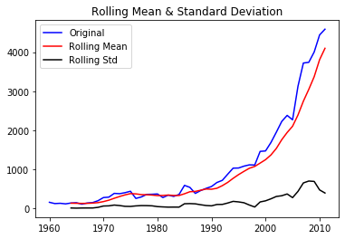

```python
#Plot rolling statistics
orig = plt.plot(timeSeries, color='blue', label='Original')
mean = plt.plot(rolmean, color='red', label='Rolling Mean')
std = plt.plot(rolstd, color='black', label='Rolling Std')
plt.legend(loc='best')
plt.title('Rolling Mean & Standard Deviation')
plt.show(block=False)
```

Pour confirmer encore notre hypothèse selon laquelle la série chronologique n'est pas stationnaire, effectuons le test ADCF.

```python
#Perform Augmented Dickey–Fuller test:
print('Results of Dickey Fuller Test:')
dftest = adfuller(timeSeries["CO2 emissions from liquid fuel consumption (kt)"], autolag='AIC')

dfoutput = pd.Series(dftest[0:4], index=['Test Statistic','p-value','#Lags Used','Number of Observations Used'])
for key,value in dftest[4].items():
    dfoutput['Critical Value (%s)'%key] = value

print(dfoutput)
```

```
Results of Dickey Fuller Test:
Test Statistic                  5.076017
p-value                         1.000000
#Lags Used                      2.000000
Number of Observations Used    49.000000
Critical Value (1%)            -3.571472
Critical Value (5%)            -2.922629
Critical Value (10%)           -2.599336
dtype: float64
```

Pour qu'une série chronologique soit stationnaire, son test ADCF doit avoir:

1. La valeur de p doit être faible (selon l'hypothèse nulle)
2. Les valeurs critiques à des intervalles de confiance de 1%, 5% et 10% doivent être aussi proches que possible des statistiques de test.

D'après le résultat du test ADCF ci-dessus, nous voyons que la valeur de p (au maximum peut être de 1,0) est très grande. Les valeurs critiques ne sont pas non plus très proches des statistiques de test. Par conséquent, nous pouvons dire en toute sécurité que **notre série chronologique pour le moment n'est pas stationnaire**

## Transformation des données pour atteindre la stationnarité

Il existe plusieurs façons d'atteindre la stationnarité grâce à la transformation des données, telles que la prise de *log10, loge*, carré, racine carrée, cube, racine cubique, décroissance exponentielle, décalage temporel, etc.

Dans notre bloc-notes, commençons par les log transformations. Notre objectif est de supprimer la composante tendance. Par conséquent, des courbes plus plates (c.-à-d. De paralle à l'axe des x) pour les séries chronologiques et rolling mean après la prise de log indiqueraient que notre transformation des données a fait du bon travail.

**Transformation pour l"'échelle logarithmique**

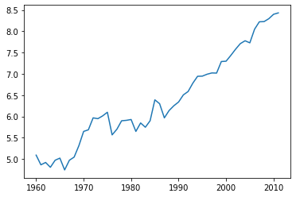

```python
#Estimating trend
timeSeries_logScale = np.log1p(timeSeries)
plt.plot(timeSeries_logScale)
```

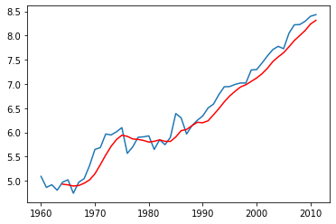

```python
#The below transformation is required to make series stationary
movingAverage = timeSeries_logScale.rolling(window=5).mean()
movingSTD = timeSeries_logScale.rolling(window=5).std()
plt.plot(timeSeries_logScale)
plt.plot(movingAverage, color='red')
```

Du graphique ci-dessus, nous voyons que même si rolling mean ( moyenne mobile) n'est pas stationnaire, elle est toujours meilleure que dans le cas précédent, où aucune transfromation n'était appliquée aux séries. Nous pouvons donc au moins dire que nous allons dans la bonne direction.

Nous savons par le graphique ci-dessus que les séries chronologiques avec échelle logarithmique ainsi que sa moyenne mobile ont une composante de tendance. Ainsi, nous pouvons appliquer une intuition élémentaire: la soustraction l'une de l'autre devrait supprimer la composante tendance des deux. C'est comme:

*log scale L = stationary part(L1) + trend(LT)*  
*moving avg of log scale A = stationary part(A1) + trend(AT)*  
*result series R = L - A = (L1+LT) - (A1+AT) = (L1-A1) + (LT-AT)*

L & A sont des series & leur moving avg, et trend sera plus ou moins la même, donc LT-AT est presque égal à 0

Ainsi, la composante tendance(trend) sera presque supprimée. Et nous avons, *R = L1 - A1*, notre dernière courbe non tendancielle

```python
datasetLogScaleMinusMovingAverage = timeSeries_logScale - movingAverage
datasetLogScaleMinusMovingAverage.head(10)

#Remove NAN values
datasetLogScaleMinusMovingAverage.dropna(inplace=True)
datasetLogScaleMinusMovingAverage.head(10)
```

| IndicatorName Year | CO2 emissions from liquid fuel consumption (kt) |
| --- | --- |
| 1964 | 0.041129 |
| 1965 | 0.104834 |
| 1966 | -0.148549 |
| 1967 | 0.068781 |
| 1968 | 0.094512 |
| 1969 | 0.294300 |
| 1970 | 0.503933 |
| 1971 | 0.353485 |
| 1972 | 0.434969 |
| 1973 | 0.235396 |

```python
def test_stationarity(timeseries):

    #Determine rolling statistics
    movingAverage = timeseries.rolling(window=5).mean()
    movingSTD = timeseries.rolling(window=5).std()

    #Plot rolling statistics
    orig = plt.plot(timeseries, color='blue', label='Original')
    mean = plt.plot(movingAverage, color='red', label='Rolling Mean')
    std = plt.plot(movingSTD, color='black', label='Rolling Std')
    plt.legend(loc='best')
    plt.title('Rolling Mean & Standard Deviation')
    plt.show(block=False)

    #Perform Dickey–Fuller test:
    print('Results of Dickey Fuller Test:')
    dftest = adfuller(timeseries["CO2 emissions from liquid fuel consumption (kt)"], autolag='AIC')
    dfoutput = pd.Series(dftest[0:4], index=['Test Statistic','p-value','#Lags Used','Number of Observations Used'])
    for key,value in dftest[4].items():
        dfoutput['Critical Value (%s)'%key] = value
    print(dfoutput)
```

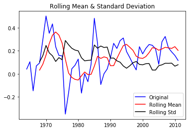

```
Results of Dickey Fuller Test:
Test Statistic                 -3.815440
p-value                         0.002753
#Lags Used                      0.000000
Number of Observations Used    47.000000
Critical Value (1%)            -3.577848
Critical Value (5%)            -2.925338
Critical Value (10%)           -2.600774
dtype: float64
```

```python
test_stationarity(datasetLogScaleMinusMovingAverage)
```

**Transformation exponentiel decroissante**

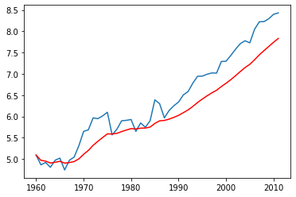

```python
exponentialDecayWeightedAverage = timeSeries_logScale.ewm(halflife=5, min_periods=0, adjust=True).mean()
plt.plot(timeSeries_logScale)
plt.plot(exponentialDecayWeightedAverage, color='red')
```

D'après le graphique ci-dessus, il semble que la décroissance exponentielle ne présente aucun avantage par rapport à l'échelle logarithmique, car les deux courbes correspondantes sont similaires. Mais, en statistiques, les inférences ne peuvent pas être tirées simplement en regardant les courbes. Par conséquent, nous effectuons à nouveau le test ADCF sur la série de désintégration ci-dessous.

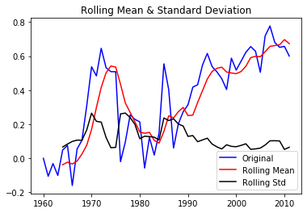

```
Results of Dickey Fuller Test:
Test Statistic                 -2.309425
p-value                         0.168946
#Lags Used                      0.000000
Number of Observations Used    51.000000
Critical Value (1%)            -3.565624
Critical Value (5%)            -2.920142
Critical Value (10%)           -2.598015
dtype: float64
```

```python
datasetLogScaleMinusExponentialMovingAverage = timeSeries_logScale - exponentialDecayWeightedAverage
test_stationarity(datasetLogScaleMinusExponentialMovingAverage)
```

**Transformation de décalage temporel**

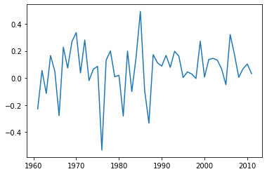

```python
datasetLogDiffShifting = timeSeries_logScale - timeSeries_logScale.shift()
plt.plot(datasetLogDiffShifting)
```

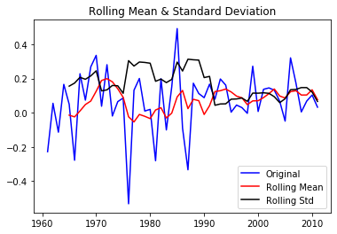

```
Results of Dickey Fuller Test:
Test Statistic                -5.958151e+00
p-value                        2.069463e-07
#Lags Used                     1.000000e+00
Number of Observations Used    4.900000e+01
Critical Value (1%)           -3.571472e+00
Critical Value (5%)           -2.922629e+00
Critical Value (10%)          -2.599336e+00
dtype: float64
```

```python
datasetLogDiffShifting.dropna(inplace=True)
test_stationarity(datasetLogDiffShifting)
```

Notre série est stationnaire

Décomposons maintenant les 3 composantes de la série des échelles logarithmiques à l'aide d'une fonction de bibliothèque système. Une fois que nous séparons nos composants, nous pouvons simplement ignorer la tendance et la saisonnalité et vérifier la nature de la partie résiduelle.

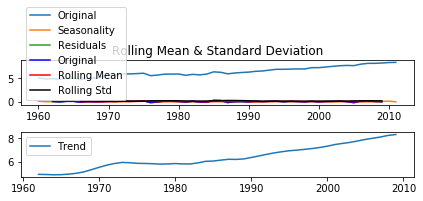

```
Results of Dickey Fuller Test:
Test Statistic                 -3.766679
p-value                         0.003267
#Lags Used                      8.000000
Number of Observations Used    39.000000
Critical Value (1%)            -3.610400
Critical Value (5%)            -2.939109
Critical Value (10%)           -2.608063
dtype: float64
```

```python
decomposition = seasonal_decompose(timeSeries_logScale, freq=5)

trend = decomposition.trend
seasonal = decomposition.seasonal
residual = decomposition.resid

plt.subplot(411)
plt.plot(timeSeries_logScale, label='Original')
plt.legend(loc='best')

plt.subplot(412)
plt.plot(trend, label='Trend')
plt.legend(loc='best')

plt.subplot(411)
plt.plot(seasonal, label='Seasonality')
plt.legend(loc='best')

plt.subplot(411)
plt.plot(residual, label='Residuals')
plt.legend(loc='best')

plt.tight_layout()

#there can be cases where an observation simply consisted of trend & seasonality. In that case, there won't be
#any residual component & that would be a null or NaN. Hence, we also remove such cases.
decomposedLogData = residual
decomposedLogData.dropna(inplace=True)
test_stationarity(decomposedLogData)
```

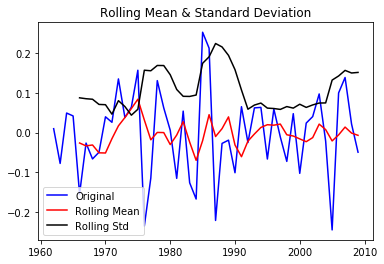

```
Results of Dickey Fuller Test:
Test Statistic                 -3.766679
p-value                         0.003267
#Lags Used                      8.000000
Number of Observations Used    39.000000
Critical Value (1%)            -3.610400
Critical Value (5%)            -2.939109
Critical Value (10%)           -2.608063
dtype: float64
```

```python
decomposedLogData = residual
decomposedLogData.dropna(inplace=True)
test_stationarity(decomposedLogData)
```

**Autocorrélation**

L'autocorrélation est la corrélation d'une série chronologique avec la même série temporelle décalée. Il résume la force d'une relation avec une observation dans une série chronologique avec des observations à des pas de temps antérieurs.

Nous créons des facteurs de facteur d'autocorrélation (ACF) et de facteur d'autocorrélation partielle (PACF) pour identifier les modèles dans les données ci-dessus qui sont stationnaires à la fois sur la moyenne et la variance. L'idée est d'identifier la présence de composants AR et MA dans les résidus.

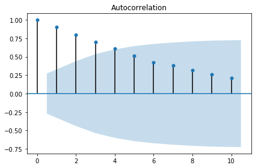

```python
#autocorrelation_plot
plot_acf(timeSeries['CO2 emissions from liquid fuel consumption (kt)'].values.squeeze(), lags=10)

plt.tight_layout()
plt.show()
```

Il y a une corrélation positive avec les 11 premiers retards qui est peut-être significative pour les 2-4 premiers retards(lags).

Un bon point de départ pour le paramètre AR du modèle peut être 4.

Essayons l'autocorrélation sur les différences ...

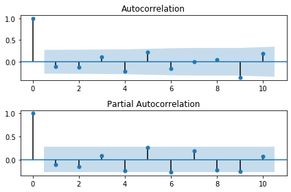

```python
# Initial approximation of parameters using Autocorrelation and Partial Autocorrelation Plots
ax = plt.subplot(211)
# Plot the autocorrelation function
#acf
plot_acf(datasetLogDiffShifting.values.squeeze(), lags=10, ax=ax)
ax = plt.subplot(212)
#pacf
plot_pacf(datasetLogDiffShifting.squeeze(), lags=10, ax=ax)
plt.tight_layout()
plt.show()
```

**Modèle ARIMA**

Moyenne mobile intégrée auto-régressive

Les modèles ARIMA sont désignés par la notation ARIMA (p, d, q). Ces paramètres tiennent compte de la saisonnalité, de la tendance et du bruit dans les ensembles de données:

p - le nombre d'observations de décalage à inclure dans le modèle, ou ordre de décalage. (AR) d - le nombre de fois que les observations brutes sont différenciées ou le degré de différenciation. (I) q - la taille de la fenêtre moyenne mobile, également appelée l'ordre de la moyenne mobile. (MA)

Nous utiliserons la valeur AIC (Akaike Information Criterion), renvoyée avec les modèles ARIMA équipés de modèles statistiques. L'AIC mesure l'adéquation d'un modèle avec les données tout en tenant compte de la complexité globale du modèle. Un modèle qui correspond très bien aux données tout en utilisant de nombreuses fonctionnalités se verra attribuer un score AIC plus élevé qu'un modèle qui utilise moins de fonctionnalités pour obtenir la même qualité d'ajustement. Par conséquent, nous sommes intéressés à trouver le modèle qui donne la valeur AIC la plus faible.

```python
# Initial approximation of parameters
qs = range(0, 4)
ps = range(0, 4)
d=1
parameters = product(ps, qs)
parameters_list = list(parameters)
len(parameters_list)


# Model Selection
results = []
best_aic = float("inf")
warnings.filterwarnings('ignore')
for param in parameters_list:
    try:
        model = ARIMA(timeSeries_logScale, order=(param[0], d, param[1])).fit(disp=-1)
    except ValueError:
        print('bad parameter combination:', param)
        continue
    aic = model.aic
    if aic < best_aic:
        best_model = model
        best_aic = aic
        best_param = param
    results.append([param, model.aic])
```

```
bad parameter combination: (1, 1)
bad parameter combination: (1, 2)
bad parameter combination: (1, 3)
bad parameter combination: (2, 3)
bad parameter combination: (3, 3)
```

```python
# Best Models
result_table = pd.DataFrame(results)
result_table.columns = ['parameters', 'aic']
print(result_table.sort_values(by = 'aic', ascending=True).head())
```

```
   parameters        aic
6      (2, 1) -32.818634
9      (3, 1) -31.238185
3      (0, 3) -30.289999
10     (3, 2) -30.118219
7      (2, 2) -29.545294
```

```python
print(best_model.summary())
```

```
                                             ARIMA Model Results
=============================================================================================================
Dep. Variable:     D.CO2 emissions from liquid fuel consumption (kt)   No. Observations:                   51
Model:                                                ARIMA(2, 1, 1)   Log Likelihood                  21.409
Method:                                                      css-mle   S.D. of innovations              0.155
Date:                                               Wed, 22 Jan 2020   AIC                            -32.819
Time:                                                       21:18:51   BIC                            -23.160
Sample:                                                            1   HQIC                           -29.128

===========================================================================================================================
                                                              coef    std err          z      P>|z|      [0.025      0.975]
---------------------------------------------------------------------------------------------------------------------------
const                                                       0.0659      0.020      3.336      0.002       0.027       0.105
ar.L1.D.CO2 emissions from liquid fuel consumption (kt)    -0.9002      0.139     -6.464      0.000      -1.173      -0.627
ar.L2.D.CO2 emissions from liquid fuel consumption (kt)    -0.2983      0.137     -2.182      0.034      -0.566      -0.030
ma.L1.D.CO2 emissions from liquid fuel consumption (kt)     0.9855      0.166      5.923      0.000       0.659       1.312
                                    Roots
=============================================================================
                  Real          Imaginary           Modulus         Frequency
-----------------------------------------------------------------------------
AR.1           -1.5089           -1.0372j            1.8310           -0.4042
AR.2           -1.5089           +1.0372j            1.8310            0.4042
MA.1           -1.0147           +0.0000j            1.0147            0.5000
-----------------------------------------------------------------------------
```

```python
print("Dickey–Fuller test:: p=%f" % adfuller(best_model.resid[11:])[1])
```

```
Dickey–Fuller test:: p=0.000000
```

```
Plotting ARIMA model
```

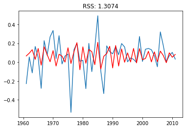

```python
# AR+I+MA = ARIMA model
#model = ARIMA(timeSeries_logScale, order=(2,1,1))
#results_ARIMA = model.fit(disp=-1)
results_ARIMA = best_model
plt.plot(datasetLogDiffShifting)
plt.plot(results_ARIMA.fittedvalues, color='red')
plt.title('RSS: %.4f'%sum((results_ARIMA.fittedvalues - datasetLogDiffShifting['CO2 emissions from liquid fuel consumption (kt)'])**2))
print('Plotting ARIMA model')
```

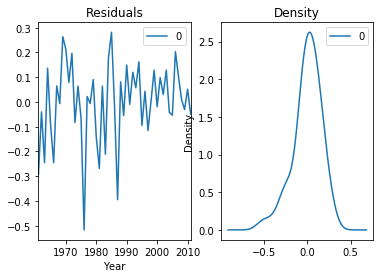

```python
# Plot residual errors
residuals = pd.DataFrame(results_ARIMA.resid)
fig, ax = plt.subplots(1,2)
residuals.plot(title="Residuals", ax=ax[0])
residuals.plot(kind='kde', title='Density', ax=ax[1])
plt.show()
```

Les erreurs résiduelles semblent fines avec une moyenne proche de zéro et une variance uniforme. Représentons les valeurs réelles par rapport aux valeurs ajustées à l'aide de .plot_predict()

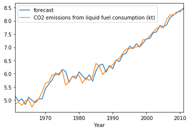

```python
# Actual vs Fitted
results_ARIMA.plot_predict(dynamic=False)
plt.show()
```

```python
predictions_ARIMA_diff = pd.Series(results_ARIMA.fittedvalues, copy=True)
print(predictions_ARIMA_diff.head())
```

```
Year
1961    0.065877
1962    0.095027
1963    0.131919
1964    0.029624
1965    0.144700
dtype: float64
```

```python
#Convert to cumulative sum
predictions_ARIMA_diff_cumsum = predictions_ARIMA_diff.cumsum()
print(predictions_ARIMA_diff_cumsum)
```

```
Year
1961    0.065877
1962    0.160904
1963    0.292823
1964    0.322447
1965    0.467146
1966    0.435449
1967    0.598414
1968    0.678937
1969    0.683306
1970    0.805498
1971    0.764435
1972    0.848262
1973    0.912182
1974    0.912923
```

[output cut: 38 more lines]

```python
predictions_ARIMA_log = pd.Series(timeSeries_logScale['CO2 emissions from liquid fuel consumption (kt)'].iloc[0], index=timeSeries_logScale.index)
predictions_ARIMA_log = predictions_ARIMA_log.add(predictions_ARIMA_diff_cumsum, fill_value=0)
predictions_ARIMA_log.head()
```

```
Year
1960    5.089742
1961    5.155619
1962    5.250646
1963    5.382565
1964    5.412189
dtype: float64
```

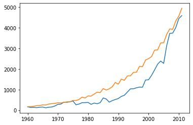

```python
# Inverse of log is exp.
predictions_ARIMA = np.exp(predictions_ARIMA_log)
plt.plot(timeSeries)
plt.plot(predictions_ARIMA)
```

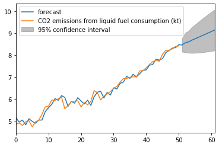

```python
#We have 50(existing data of 50 yrs) data points.
#And we want to forecast for additional 10 data points or 10 yrs.
results_ARIMA.plot_predict(1,62)
x=results_ARIMA.forecast(steps=10)
```

```python
print(x[0])
print(len(x[0]))
print(np.exp(x[0]))
```

```
[8.46762772 8.57005507 8.61184199 8.68850177 8.75185848 8.81678794
 8.88426987 8.94898499 9.01542934 9.0811424 ]
10
[4758.21424576 5271.4201024  5496.36359555 5934.2846404  6322.42730351
 6746.5594381  7217.54303331 7700.07224351 8229.07869806 8787.99972275]
```